# IODS course project

Jani Koskinen

# Introduction to Open Data Science - Course Project

# About the project

```r
# This is a so-called "R chunk" where you can write R code.

date()
```

```
## [1] "Sat Nov 20 22:31:11 2021"
```

## About me

I have used *R and RStudio* quite a lot in my work. I’m familiar with *Git and Github*, but have not become ‘fluent’ with them yet – in fact, using them has always felt a bit cumbersome. I hope this course will help me get better with using Git/GitHub.

I heard about the course from my supervisor and department mailing list.

Here is a link to my github page for this project:**https://github.com/jpkos/IODS-project**

List test:

- First item
- Second item

# Chapter 2: Linear regression practice

In this exercise, we are using linear regression to evaluate how different learning approaches affect student’s performance in a statistics course.

We will start off by loading the libraries

```r
library(dplyr)
library(GGally)
library(ggplot2)
```

## Read and describe the data

In the data wrangling section, we created a csv file with the data. Let’s load that.

```r
data <- read.csv("data/learning2014_csv.csv")
```

Pick only the combined columns and the columns with participant info

```r
cols <- c("Age", "Attitude", "Points", "gender", "deep", "surf", "stra")
data <- data[cols]
```

Data overview (dimensions [rows and cols] and structure [variables and their datatypes])

```r
dim(data)
```

```
## [1] 166   7
```

```r
str(data)
```

```
## 'data.frame':    166 obs. of  7 variables:
##  $ Age     : int  53 55 49 53 49 38 50 37 37 42 ...
##  $ Attitude: int  37 31 25 35 37 38 35 29 38 21 ...
##  $ Points  : int  25 12 24 10 22 21 21 31 24 26 ...
##  $ gender  : chr  "F" "M" "F" "M" ...
##  $ deep    : num  3.58 2.92 3.5 3.5 3.67 ...
##  $ surf    : num  2.58 3.17 2.25 2.25 2.83 ...
##  $ stra    : num  3.38 2.75 3.62 3.12 3.62 ...
```

THe dataset is about how students learning approaches affect their exam points in a statistics course. The data has combined variables that describe students learning approaches (deep, surface, strategic) and individual variables with participant information (age, gender, attitude towards statistics, exam points)

Summary of the variables:

```r
summary(data)
```

```
##       Age           Attitude         Points         gender
##  Min.   :17.00   Min.   :14.00   Min.   : 7.00   Length:166
##  1st Qu.:21.00   1st Qu.:26.00   1st Qu.:19.00   Class :character
##  Median :22.00   Median :32.00   Median :23.00   Mode  :character
##  Mean   :25.51   Mean   :31.43   Mean   :22.72
##  3rd Qu.:27.00   3rd Qu.:37.00   3rd Qu.:27.75
##  Max.   :55.00   Max.   :50.00   Max.   :33.00
##       deep            surf            stra
##  Min.   :1.583   Min.   :1.583   Min.   :1.250
##  1st Qu.:3.333   1st Qu.:2.417   1st Qu.:2.625
##  Median :3.667   Median :2.833   Median :3.188
##  Mean   :3.680   Mean   :2.787   Mean   :3.121
##  3rd Qu.:4.083   3rd Qu.:3.167   3rd Qu.:3.625
##  Max.   :4.917   Max.   :4.333   Max.   :5.000
```

Plot variable pairs to visualize correlations

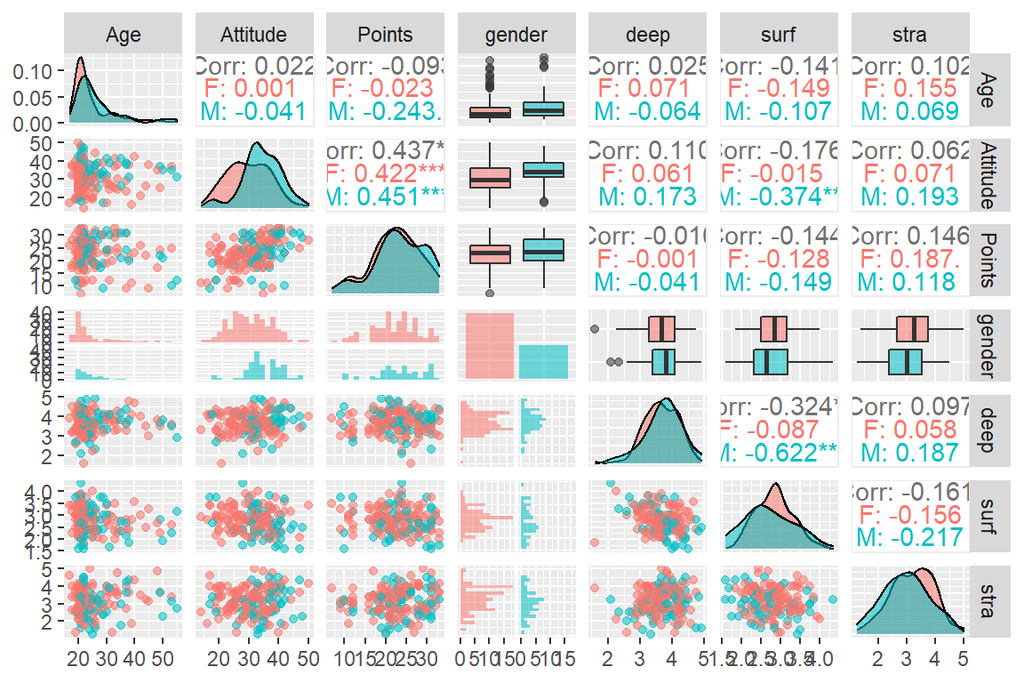

```r
p <- ggpairs(data, mapping = aes(col=gender, alpha=0.3), lower = list(combo = wrap("facethist", bins = 20)))
p
```

## Linear regression models

Let’s fit a model with three variables (strategic approach, surface approach, attitude) and the exam points as the target variable

```r
model <- lm(Points ~ stra + surf + Attitude, data=data)
summary(model)
```

```
##
## Call:
## lm(formula = Points ~ stra + surf + Attitude, data = data)
##
## Residuals:
##      Min       1Q   Median       3Q      Max
## -17.1550  -3.4346   0.5156   3.6401  10.8952
##
## Coefficients:
##             Estimate Std. Error t value Pr(>|t|)
## (Intercept) 11.01711    3.68375   2.991  0.00322 **
## stra         0.85313    0.54159   1.575  0.11716
## surf        -0.58607    0.80138  -0.731  0.46563
## Attitude     0.33952    0.05741   5.913 1.93e-08 ***
## ---
## Signif. codes:  0 '***' 0.001 '**' 0.01 '*' 0.05 '.' 0.1 ' ' 1
##
## Residual standard error: 5.296 on 162 degrees of freedom
## Multiple R-squared:  0.2074, Adjusted R-squared:  0.1927
## F-statistic: 14.13 on 3 and 162 DF,  p-value: 3.156e-08
```

Attitude has a significant effect, the others do not. Let’s fit another model, this time only with Attitude

```r
model2 <- lm(Points ~ Attitude, data=data)
summary(model2)
```

```
##
## Call:
## lm(formula = Points ~ Attitude, data = data)
##
## Residuals:
##      Min       1Q   Median       3Q      Max
## -16.9763  -3.2119   0.4339   4.1534  10.6645
##
## Coefficients:
##             Estimate Std. Error t value Pr(>|t|)
## (Intercept) 11.63715    1.83035   6.358 1.95e-09 ***
## Attitude     0.35255    0.05674   6.214 4.12e-09 ***
## ---
## Signif. codes:  0 '***' 0.001 '**' 0.01 '*' 0.05 '.' 0.1 ' ' 1
##
## Residual standard error: 5.32 on 164 degrees of freedom
## Multiple R-squared:  0.1906, Adjusted R-squared:  0.1856
## F-statistic: 38.61 on 1 and 164 DF,  p-value: 4.119e-09
```

The multiple R-squared measures how well the model fits the data, but also adjusts to the number of fitted variables. The multiple R-squared for the first model was 0.2074. This can be interpreted to mean that the model explains roughly 20.7% of the variance in the data. When we fit the model again with only Attitude as the variable, the R-squared is 0.1906 (~19.1%), meaning that Attitude alone explained a lot of the variance seen in the data.

Diagnosis plots:

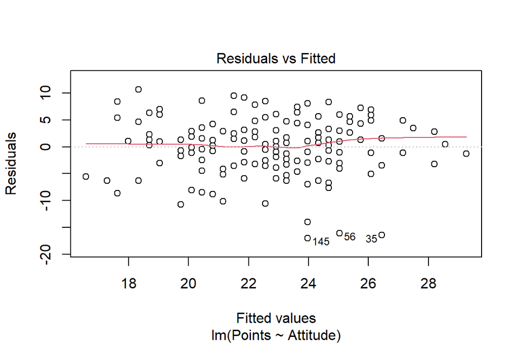

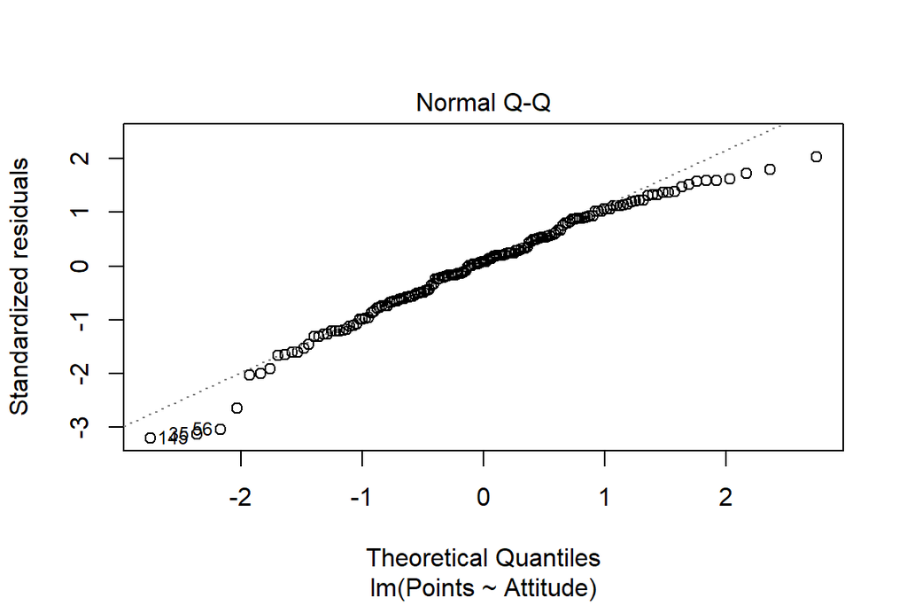

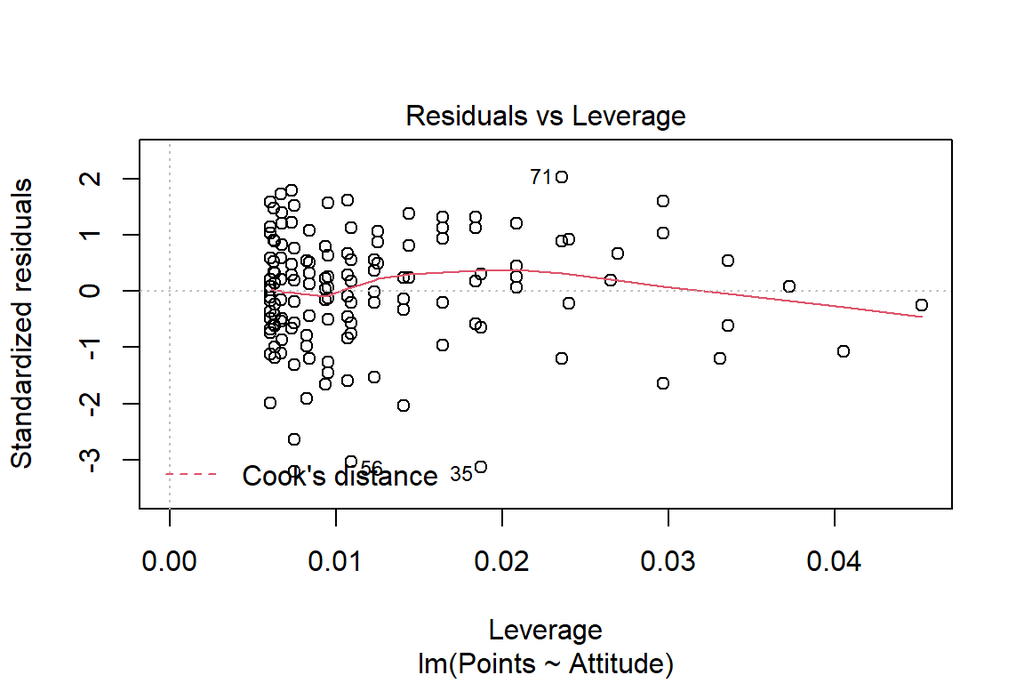

```r
plot(model2, c(1,2,5))
```

In the residuals vs fitted plot, we can see that with larger values the residuals may be getting smaller, although the number of data points is also smaller. Overall there does not seem to be serious heteroscedasticity (residuals should not depend on the fitted values, i.e. they should be randomly distributed).

The QQ-plot shows some deviation from normalcy at the extreme values, however the deviations are smallish and may not violate normality assumptions (errors should be normally distributed).

The residuals vs leverage plot shows that while there are a few points that are kind of outliers, they most likely do not seriously affect the model results.

Finally, let’s plot points vs attitude.

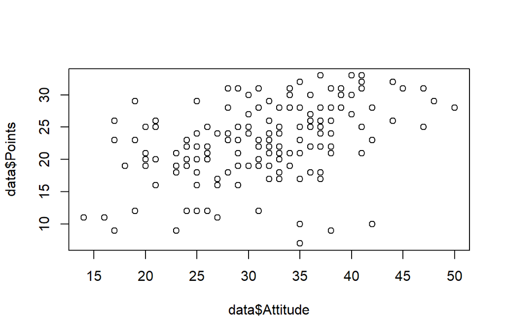

```r
plot(data$Attitude, data$Points)
```

# Chapter 3: Logistic regression practice

Let’s start by loading the necessary libraries

```r
library(dplyr)
library(GGally)
library(ggplot2)
library(tidyr)
library(caret)
```

## Dataset description

Load the data we processed in the data wrangling section (actually, I’m using the ready made dataset)

```r
data <- read.csv("data/student/alc.csv")
```

Print a summary of the data structure

```r
str(data)
```

```
## 'data.frame':    370 obs. of  51 variables:
##  $ school    : chr  "GP" "GP" "GP" "GP" ...
##  $ sex       : chr  "F" "F" "F" "F" ...
##  $ age       : int  15 15 15 15 15 15 15 15 15 15 ...
##  $ address   : chr  "R" "R" "R" "R" ...
##  $ famsize   : chr  "GT3" "GT3" "GT3" "GT3" ...
##  $ Pstatus   : chr  "T" "T" "T" "T" ...
##  $ Medu      : int  1 1 2 2 3 3 3 2 3 3 ...
##  $ Fedu      : int  1 1 2 4 3 4 4 2 1 3 ...
##  $ Mjob      : chr  "at_home" "other" "at_home" "services" ...
##  $ Fjob      : chr  "other" "other" "other" "health" ...
##  $ reason    : chr  "home" "reputation" "reputation" "course" ...
##  $ guardian  : chr  "mother" "mother" "mother" "mother" ...
##  $ traveltime: int  2 1 1 1 2 1 2 2 2 1 ...
##  $ studytime : int  4 2 1 3 3 3 3 2 4 4 ...
```

[output cut: 37 more lines]

The data describes each subjects school performance together with different study and personal information such as absences (from school), failures (at school), age, family size, education level, etc. G1, G2 and G3 are the grades in three different periods for the given course subject (portuguese or math). Alcohol level is a binary variable (high/low usage).

# Analysis

We will analyse students’ alcohol consumption and its effects on 4 different variables. The dependent variable is high alcohol use (high_use), with the following independent variables and the hypotheses:

1. Absences: Students that have more absences are more likely to have high alcohol use
2. Failures: Students with more failues are more likely to have high alcohol use
3. Sex: Men are more likely to have higher alcohol use
4. Romantic: People who are in a relationship are less likely to have high alcohol use

First, let’s plot the distributions of these variables:

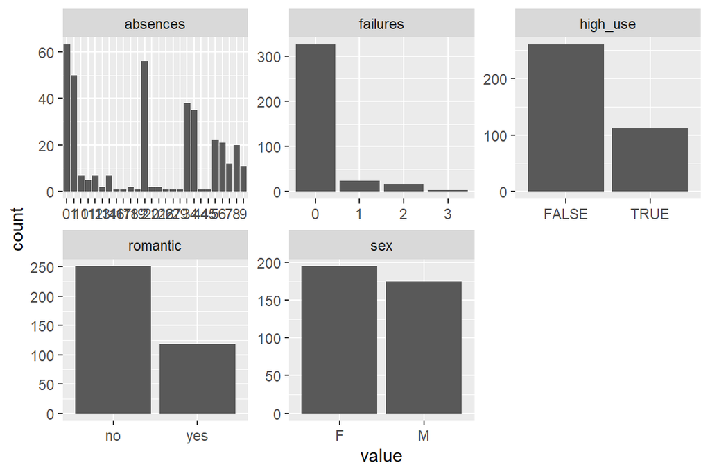

```r
cols <- c("sex", "failures", "absences", "romantic", "high_use")
gather(data[cols]) %>% ggplot(aes(value)) + facet_wrap("key", scales="free") + geom_bar()
```

Fit a model with these variables:

```r
model <- glm(high_use ~ absences + failures + sex + romantic, data=data, family="binomial")
summary(model)
```

```
##
## Call:
## glm(formula = high_use ~ absences + failures + sex + romantic,
##     family = "binomial", data = data)
##
## Deviance Residuals:
##     Min       1Q   Median       3Q      Max
## -2.1132  -0.8415  -0.5849   1.0329   2.1106
##
## Coefficients:
##             Estimate Std. Error z value Pr(>|z|)
## (Intercept) -1.86714    0.24303  -7.683 1.56e-14 ***
## absences     0.09406    0.02323   4.049 5.15e-05 ***
## failures     0.60568    0.20812   2.910  0.00361 **
## sexM         0.98393    0.24789   3.969 7.21e-05 ***
## romanticyes -0.24606    0.26635  -0.924  0.35558
## ---
## Signif. codes:  0 '***' 0.001 '**' 0.01 '*' 0.05 '.' 0.1 ' ' 1
##
## (Dispersion parameter for binomial family taken to be 1)
##
##     Null deviance: 452.04  on 369  degrees of freedom
## Residual deviance: 406.13  on 365  degrees of freedom
## AIC: 416.13
##
## Number of Fisher Scoring iterations: 4
```

According to the results:

- Absences correlated with higher probability of high alcohol use, the log odds increase by 0.094, and the increase is statistically significant (z = 4.049, p<0.001).
- Failures correlated with higher probability of igh alcohol use, log odds increase by 0.605, and the increase is statistically significant (z = 2.910, p=0.004).
- Men had had higher probability of high alcohol use, log odds increase by 0.98, and the increase is statistically significant4 (z = 3.969, p<0.001).
- Being in a relationship decreased the chance of higher alcohol use, log odds decrease by -0.246, but the change was not significant, (-0.924, p=0.356).

Hypotheses 1 - 3 were supported by the data. For hypothesis 4, the effect was negative as predicted, but the effect is not statistically significant.

The confidence intervals of these variables are:

```r
confint(model)
```

```
##                   2.5 %     97.5 %
## (Intercept) -2.36326577 -1.4080742
## absences     0.05079132  0.1421351
## failures     0.20530644  1.0277095
## sexM         0.50384493  1.4776693
## romanticyes -0.77779991  0.2691722
```

We can also interpret the coefficients as odds ratios by running them through the exponent function

```r
coef(model) %>% exp
```

```
## (Intercept)    absences    failures        sexM romanticyes
##   0.1545656   1.0986256   1.8324980   2.6749408   0.7818748
```

Now the coefficients indicate e.g. being Male increases the odds of high alcohol use by 2.675, and so on.

Let’s compare predicted vs real results with a 2x2 table

```r
predictions <- as.factor(predict(model, newdata = data, type = "response")>0.5)
true = as.factor(data$high_use)
confusionMatrix(data=predictions, reference=true)
```

```
## Confusion Matrix and Statistics
##
##           Reference
## Prediction FALSE TRUE
##      FALSE   247   77
##      TRUE     12   34
##
##                Accuracy : 0.7595
##                  95% CI : (0.7126, 0.8021)
##     No Information Rate : 0.7
##     P-Value [Acc > NIR] : 0.006538
##
##                   Kappa : 0.3122
##
##  Mcnemar's Test P-Value : 1.169e-11
##
##             Sensitivity : 0.9537
##             Specificity : 0.3063
##          Pos Pred Value : 0.7623
##          Neg Pred Value : 0.7391
##              Prevalence : 0.7000
##          Detection Rate : 0.6676
##    Detection Prevalence : 0.8757
##       Balanced Accuracy : 0.6300
##
##        'Positive' Class : FALSE
##
```

Total proportion of inaccurate results: 77 + 12 = 89. Total number of values was 370, so 89/370 = 0.2405 or about 24% of the data was predicted with the wrong label.

To see if this is a good result, we consider what result could be achieved with random chance. If we just flipped coins, we would get 50% correct. The logistic regression model is clearly better than that. *However*, we can also see that the proportion of non-high users is much larger than the proportion of high alcohol users. There are 259 non-high users versus 111 high users. Thus, ff we had a model that predicted everyone as non-high user, we would get 70% correct. Therefore, we can see that the model is actually not that much better than a model “no one is high user”.

# Chapter 4: Clustering and classification practice

As usual, let’s start with loading the libraries:

```r
library(dplyr)
library(GGally)
library(ggplot2)
library(tidyr)
library(caret)
library(MASS)
```

## Dataset

Load the Boston dataset from the MASS package

```r
data("Boston")
```

Explore the data

```r
summary(Boston)
```

```
##       crim                zn             indus            chas
##  Min.   : 0.00632   Min.   :  0.00   Min.   : 0.46   Min.   :0.00000
##  1st Qu.: 0.08205   1st Qu.:  0.00   1st Qu.: 5.19   1st Qu.:0.00000
##  Median : 0.25651   Median :  0.00   Median : 9.69   Median :0.00000
##  Mean   : 3.61352   Mean   : 11.36   Mean   :11.14   Mean   :0.06917
##  3rd Qu.: 3.67708   3rd Qu.: 12.50   3rd Qu.:18.10   3rd Qu.:0.00000
##  Max.   :88.97620   Max.   :100.00   Max.   :27.74   Max.   :1.00000
##       nox               rm             age              dis
##  Min.   :0.3850   Min.   :3.561   Min.   :  2.90   Min.   : 1.130
##  1st Qu.:0.4490   1st Qu.:5.886   1st Qu.: 45.02   1st Qu.: 2.100
##  Median :0.5380   Median :6.208   Median : 77.50   Median : 3.207
##  Mean   :0.5547   Mean   :6.285   Mean   : 68.57   Mean   : 3.795
##  3rd Qu.:0.6240   3rd Qu.:6.623   3rd Qu.: 94.08   3rd Qu.: 5.188
##  Max.   :0.8710   Max.   :8.780   Max.   :100.00   Max.   :12.127
##       rad              tax           ptratio          black
##  Min.   : 1.000   Min.   :187.0   Min.   :12.60   Min.   :  0.32
##  1st Qu.: 4.000   1st Qu.:279.0   1st Qu.:17.40   1st Qu.:375.38
##  Median : 5.000   Median :330.0   Median :19.05   Median :391.44
##  Mean   : 9.549   Mean   :408.2   Mean   :18.46   Mean   :356.67
##  3rd Qu.:24.000   3rd Qu.:666.0   3rd Qu.:20.20   3rd Qu.:396.23
##  Max.   :24.000   Max.   :711.0   Max.   :22.00   Max.   :396.90
##      lstat            medv
##  Min.   : 1.73   Min.   : 5.00
##  1st Qu.: 6.95   1st Qu.:17.02
##  Median :11.36   Median :21.20
##  Mean   :12.65   Mean   :22.53
##  3rd Qu.:16.95   3rd Qu.:25.00
##  Max.   :37.97   Max.   :50.00
```

```r
str(Boston)
```

```
## 'data.frame':    506 obs. of  14 variables:
##  $ crim   : num  0.00632 0.02731 0.02729 0.03237 0.06905 ...
##  $ zn     : num  18 0 0 0 0 0 12.5 12.5 12.5 12.5 ...
##  $ indus  : num  2.31 7.07 7.07 2.18 2.18 2.18 7.87 7.87 7.87 7.87 ...
##  $ chas   : int  0 0 0 0 0 0 0 0 0 0 ...
##  $ nox    : num  0.538 0.469 0.469 0.458 0.458 0.458 0.524 0.524 0.524 0.524 ...
##  $ rm     : num  6.58 6.42 7.18 7 7.15 ...
##  $ age    : num  65.2 78.9 61.1 45.8 54.2 58.7 66.6 96.1 100 85.9 ...
##  $ dis    : num  4.09 4.97 4.97 6.06 6.06 ...
##  $ rad    : int  1 2 2 3 3 3 5 5 5 5 ...
##  $ tax    : num  296 242 242 222 222 222 311 311 311 311 ...
##  $ ptratio: num  15.3 17.8 17.8 18.7 18.7 18.7 15.2 15.2 15.2 15.2 ...
##  $ black  : num  397 397 393 395 397 ...
##  $ lstat  : num  4.98 9.14 4.03 2.94 5.33 ...
##  $ medv   : num  24 21.6 34.7 33.4 36.2 28.7 22.9 27.1 16.5 18.9 ...
```

The dataset describes the housing values in Boston and includes several values that could potentially affect housing values. These include: crime rate (crim), average number of rooms per house (rm), nitrogen oxide concentration (nox), property tax (tax), black (proportion of black residents), and so on.

Let us next create graphical plots of the dataset to visualize correlations:

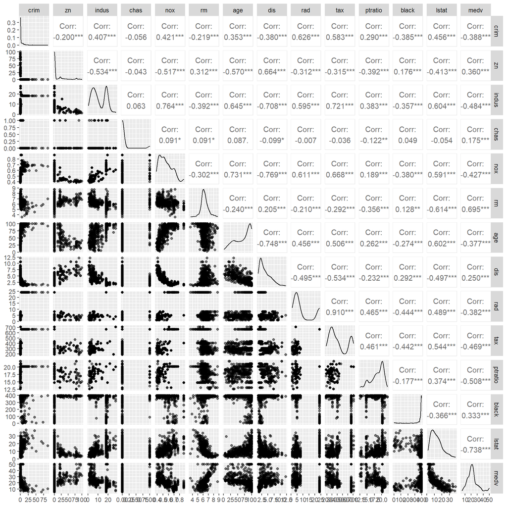

```r
ggpairs(Boston, mapping = aes(alpha=0.3), lower = list(combo = wrap("facethist", bins = 20)))
```

The strongest correlations with median housing value are:

- lstat (lower status of the population): -0.738. More lower class (less educated, poor employment) population will decrease housing prices.
- rm (average number of rooms): 0.695. More rooms will increase price.
- ptratio (pupil-teacher ratio): -0.508. Bigger P-T ratios (pupils per teacher) decrease prices.
- indus (proportion of non-retail business acres): -0.484. More land reserved for businesses will decrease housing value.

Each of the 4 strongest correlations make sense intuitively.

Show summary of the data:

```r
summary(Boston)
```

```
##       crim                zn             indus            chas
##  Min.   : 0.00632   Min.   :  0.00   Min.   : 0.46   Min.   :0.00000
##  1st Qu.: 0.08205   1st Qu.:  0.00   1st Qu.: 5.19   1st Qu.:0.00000
##  Median : 0.25651   Median :  0.00   Median : 9.69   Median :0.00000
##  Mean   : 3.61352   Mean   : 11.36   Mean   :11.14   Mean   :0.06917
##  3rd Qu.: 3.67708   3rd Qu.: 12.50   3rd Qu.:18.10   3rd Qu.:0.00000
##  Max.   :88.97620   Max.   :100.00   Max.   :27.74   Max.   :1.00000
##       nox               rm             age              dis
##  Min.   :0.3850   Min.   :3.561   Min.   :  2.90   Min.   : 1.130
##  1st Qu.:0.4490   1st Qu.:5.886   1st Qu.: 45.02   1st Qu.: 2.100
##  Median :0.5380   Median :6.208   Median : 77.50   Median : 3.207
##  Mean   :0.5547   Mean   :6.285   Mean   : 68.57   Mean   : 3.795
##  3rd Qu.:0.6240   3rd Qu.:6.623   3rd Qu.: 94.08   3rd Qu.: 5.188
##  Max.   :0.8710   Max.   :8.780   Max.   :100.00   Max.   :12.127
##       rad              tax           ptratio          black
##  Min.   : 1.000   Min.   :187.0   Min.   :12.60   Min.   :  0.32
##  1st Qu.: 4.000   1st Qu.:279.0   1st Qu.:17.40   1st Qu.:375.38
##  Median : 5.000   Median :330.0   Median :19.05   Median :391.44
##  Mean   : 9.549   Mean   :408.2   Mean   :18.46   Mean   :356.67
##  3rd Qu.:24.000   3rd Qu.:666.0   3rd Qu.:20.20   3rd Qu.:396.23
##  Max.   :24.000   Max.   :711.0   Max.   :22.00   Max.   :396.90
##      lstat            medv
##  Min.   : 1.73   Min.   : 5.00
##  1st Qu.: 6.95   1st Qu.:17.02
##  Median :11.36   Median :21.20
##  Mean   :12.65   Mean   :22.53
##  3rd Qu.:16.95   3rd Qu.:25.00
##  Max.   :37.97   Max.   :50.00
```

Some notes about this summary:

- age: this is the % of houses built before 1940. The median % is 77.5, so most of the houses are pre-1940s (data was collected in 1970s, so not that old at the time)

## Analysis

### LDA

Scale the dataset

```r
Boston <- data.frame(scale(Boston))
summary(Boston)
```

```
##       crim                 zn               indus              chas
##  Min.   :-0.419367   Min.   :-0.48724   Min.   :-1.5563   Min.   :-0.2723
##  1st Qu.:-0.410563   1st Qu.:-0.48724   1st Qu.:-0.8668   1st Qu.:-0.2723
##  Median :-0.390280   Median :-0.48724   Median :-0.2109   Median :-0.2723
##  Mean   : 0.000000   Mean   : 0.00000   Mean   : 0.0000   Mean   : 0.0000
##  3rd Qu.: 0.007389   3rd Qu.: 0.04872   3rd Qu.: 1.0150   3rd Qu.:-0.2723
##  Max.   : 9.924110   Max.   : 3.80047   Max.   : 2.4202   Max.   : 3.6648
##       nox                rm               age               dis
##  Min.   :-1.4644   Min.   :-3.8764   Min.   :-2.3331   Min.   :-1.2658
##  1st Qu.:-0.9121   1st Qu.:-0.5681   1st Qu.:-0.8366   1st Qu.:-0.8049
##  Median :-0.1441   Median :-0.1084   Median : 0.3171   Median :-0.2790
##  Mean   : 0.0000   Mean   : 0.0000   Mean   : 0.0000   Mean   : 0.0000
##  3rd Qu.: 0.5981   3rd Qu.: 0.4823   3rd Qu.: 0.9059   3rd Qu.: 0.6617
##  Max.   : 2.7296   Max.   : 3.5515   Max.   : 1.1164   Max.   : 3.9566
##       rad               tax             ptratio            black
##  Min.   :-0.9819   Min.   :-1.3127   Min.   :-2.7047   Min.   :-3.9033
##  1st Qu.:-0.6373   1st Qu.:-0.7668   1st Qu.:-0.4876   1st Qu.: 0.2049
##  Median :-0.5225   Median :-0.4642   Median : 0.2746   Median : 0.3808
##  Mean   : 0.0000   Mean   : 0.0000   Mean   : 0.0000   Mean   : 0.0000
##  3rd Qu.: 1.6596   3rd Qu.: 1.5294   3rd Qu.: 0.8058   3rd Qu.: 0.4332
##  Max.   : 1.6596   Max.   : 1.7964   Max.   : 1.6372   Max.   : 0.4406
##      lstat              medv
##  Min.   :-1.5296   Min.   :-1.9063
##  1st Qu.:-0.7986   1st Qu.:-0.5989
##  Median :-0.1811   Median :-0.1449
##  Mean   : 0.0000   Mean   : 0.0000
##  3rd Qu.: 0.6024   3rd Qu.: 0.2683
##  Max.   : 3.5453   Max.   : 2.9865
```

Now each variable has mean 0 and std 1. Next, we will categorize the crime rate variable into quantiles

```r
quants <- quantile(Boston$crim)
crimerate <- cut(Boston$crim, breaks=quants, include.lowest=TRUE)
```

Drop crimerate from original dataset

```r
Boston2 <- Boston[,!(names(Boston) %in% c("crim"))]
Boston2$crim_cat <- crimerate
```

Divide into train/val datasets with 80% ratio

```r
train_ind <- sample(nrow(Boston2), nrow(Boston2)*0.8)
Boston2.train <- Boston2[train_ind,]
Boston2.test <- Boston2[-train_ind,]
```

Fit Linear Discrimant Analysis (LDA)

```r
lda.model <- lda(crim_cat ~., data=Boston2.train)
```

### K-means

Next we will explore the data using clustering methods, namely the k-means clustering approach. First, fit the model using k=4:

```r
km.model <- kmeans(Boston, centers=4)
```

Plot results

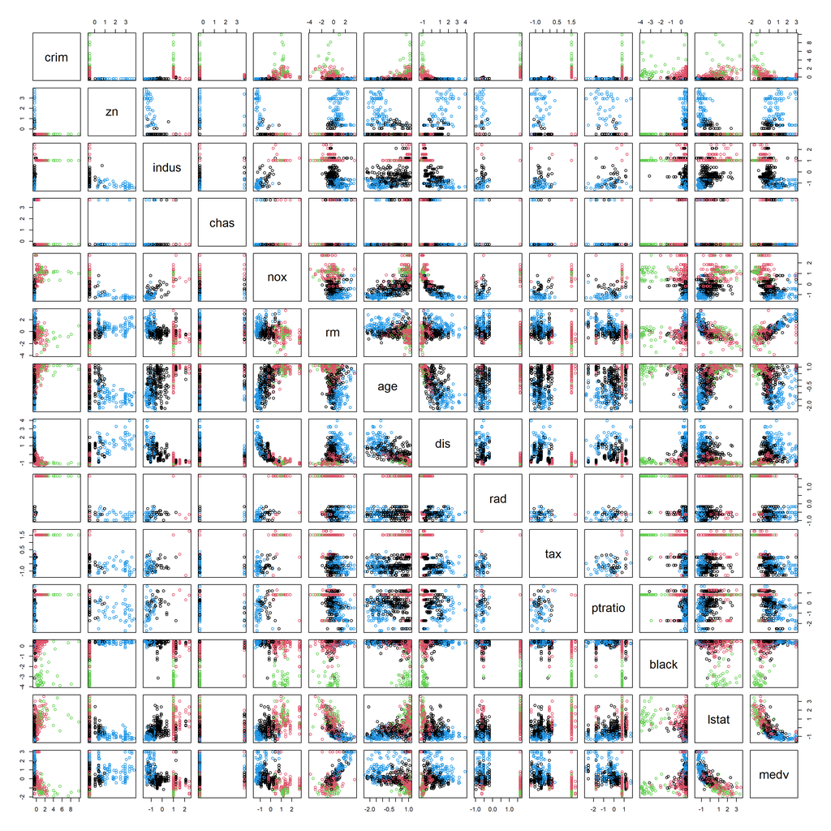

```r
pairs(Boston, col=km.model$cluster)
```

We can optimize the number of clusters by finding k so that the sum of squared errors within clusters is minimized. Using the code from DataCamp:

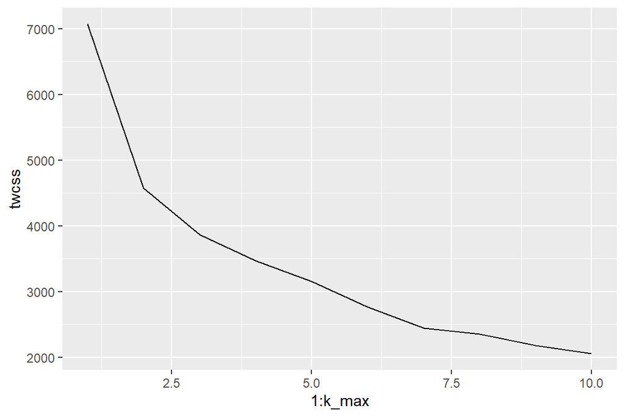

```r
k_max <- 10

# calculate the total within sum of squares
twcss <- sapply(1:k_max, function(k){kmeans(Boston, k)$tot.withinss})

# visualize the results
qplot(x = 1:k_max, y = twcss, geom = 'line')
```

There is a sharp drop at k=2, and after that the drops are more gradual. We can plot kmeans with k=2.

```r
km.model2 <- kmeans(Boston, centers=2)
```

Plot

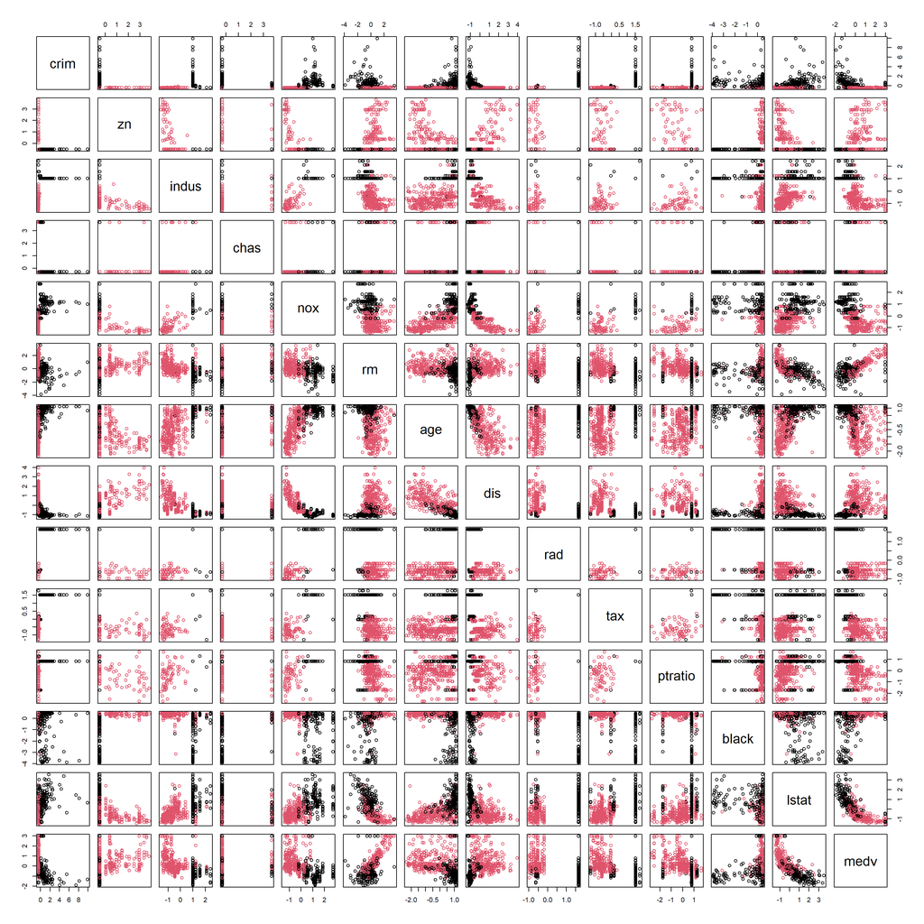

```r
pairs(Boston, col=km.model2$cluster)
```

It seems that 2 is indeed a good number of clusters; visual inspections shows that there are no clear outliers (i.e. possible third clusters that stick out)